# Probability of Component 1 Failing First vs Bias

Here I plot the bias in the scale and shape parameters for components 1 and 2, with the x-axis representing the probability that component 1 fails first. The scenario considered is where the sample size $n=100$ and no masking the component cause of failure ($p=0$) and no right-censoring ($q = 1$, or $\tau = \infty$).

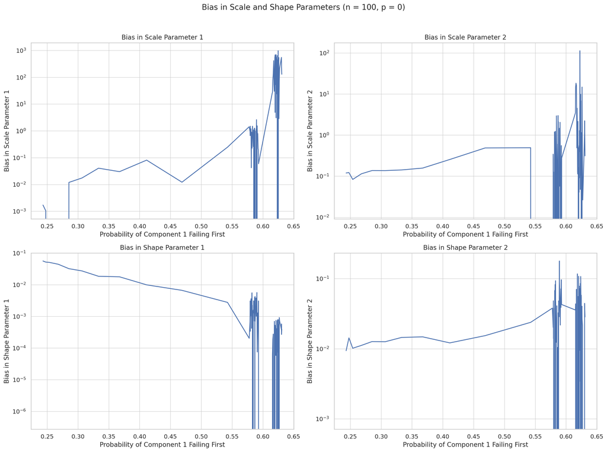

```r
knitr::include_graphics("./new-plots/prob-vs-bias-n100-p0-q1-instability.png")
```

- Top Left: Bias in Scale Parameter for Component 1
- Top Right: Bias in Scale Parameter for Component 2
- Bottom Left: Bias in Shape Parameter for Component 1
- Bottom Right: Bias in Shape Parameter for Component 2

These plots provide insights into how the bias in the estimated parameters changes with the probability of component 1 failing first.

## Observations

### Instabilities

We see some instability starting around the probability of component 1 being the cause of failure (x-axis) at around $\Pr\{K_i = 1\} = 0.55$. At this point, the bias in the scale parameter for component 1 starts exhibiting eradic behavior. This is most likely due numerical instability issues. This is a pathological case where the MTTF of component 1 is very large, and the MTTF of components 2 and 3 are only $2$. For instance, the MTTF at $\Pr\{K_i = 1\} = 0.624$ is around $10^158$, such that component $1$ either fails immediately, or can be expected to last for a very long time.

Since we are dealing with very large and very small numbers in complex calculations using floating-point arithmetic, numerical instability issues are not unexpected, since errors propagate through calculations, leading to incorrect or imprecise results.

Note that while the MTTF of component 1 is very large, the MTTF of components 2 and 3 are only $2$. There is a non-linear relationship between the MTTF of a component, and its probability of being the component cause of failrue, particularly if some components have increasing failure rates and others have decreasing failure rates. In this scenario, every component has a decreasing failure rate, and we vary the the failure rate, and the component cause of failure, of component 1 to see how it impacts the bias of the MLEs.

### Bias in Scale Parameter for Component 1